# Data Preprocessing

This is an R script for preprocessing the received data file 'testdata.csv'. The original file was locked as read-only, and a copy, dubbed simply 'data.csv' was used to prevent accidental changes to the original file.

```r
#============================================================#
#                                                            #
# General exploration of the data and preprocessing          #
#                                                            #
# @author Damian Satterthwaite-Phillips <damiansp@gmail.com> #
# @version 21 Sep 2016                                       #
#                                                            #
#============================================================#

# Start with a clean workspspace:
rm(list = ls())

# Library imports
#install.packages('sm', dependcies = T)     # etc, if not installed
library(sm)
```

Some preprocessing was done even prior to running this script:

- Changed original file to read only (> chmod a-w)
- Made copy, 'data.csv' to edit
- Filled blanks with NA
- moved 'revenue' (response var) to first field to mirror R formulae, e.g. lm(y ~ .)

Read in the .csv file, look at summary data, and summary visuals.

```r
data <- read.csv('~/Desktop/cbtnuggetsbusinessanalyticsproject/revenue/data.csv')
dim(data) # 117 records, 42 vars
```

```
## [1] 117  42
```

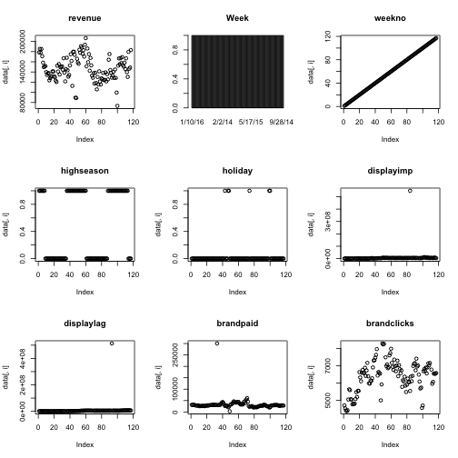

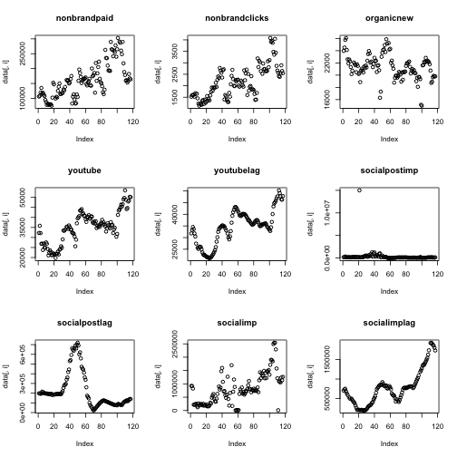

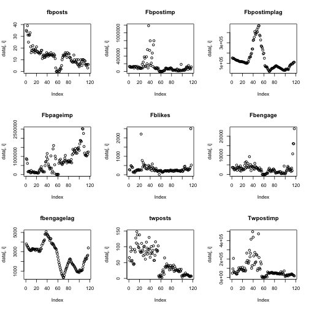

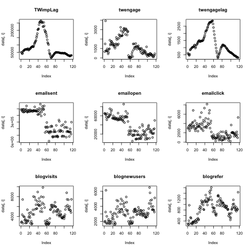

```r
# summary(data) # output commented out here

# Eyeball data visually, 9 variables at a time, to check for potential
# outliers, data distributions, etc.
par(mfrow = c(3, 3))
for (i in 1:dim(data)[2]) {
  plot(data[, i], main = names(data)[i])
#  if (i %% 9 == 0 ) { pause() }     # uncomment when not knitting
}
```

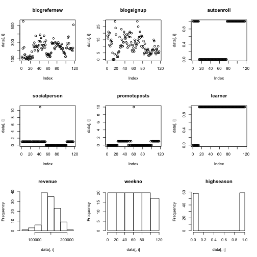

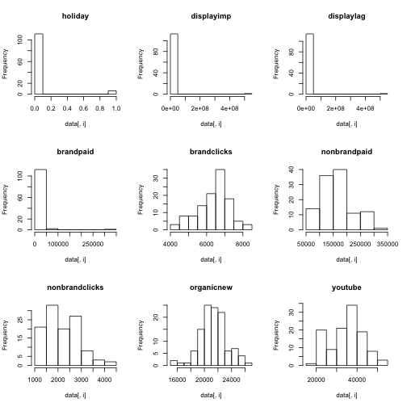

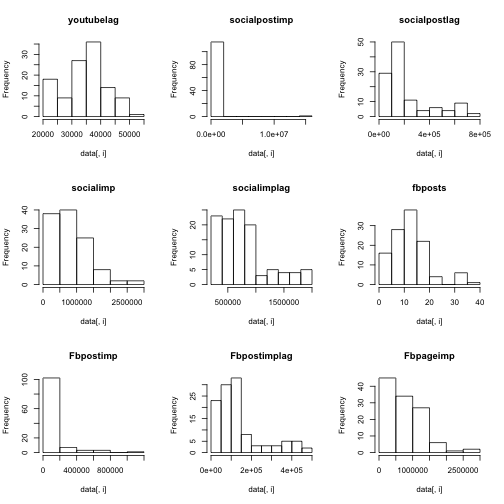

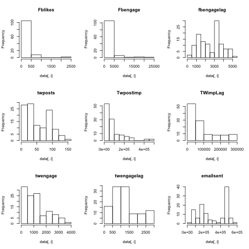

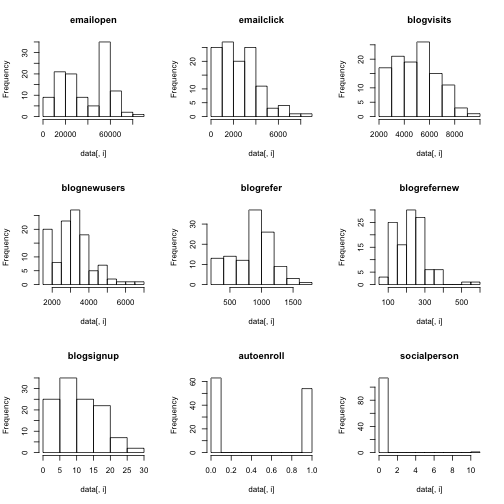

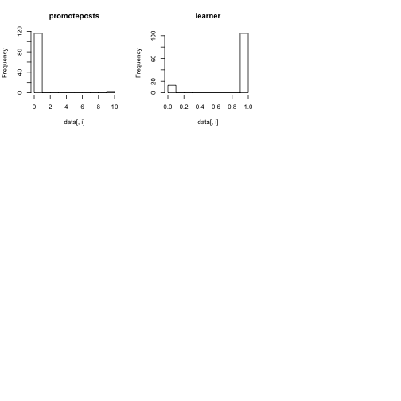

```r
n <- 0

for (i in 1:dim(data)[2]) {
  if (class(data[, i]) != 'factor') {
    hist(data[, i], main = names(data)[i])
    n <- n + 1
  }

#  if (n %% 9 == 0 ) { pause() }     # uncomment when not knitting
}
```

### Observations:

- These are time series, and time is clearly an important element
- Each record is a week's data; ordered temporally (top dates = oldest)
- Binary variables present (change to categorical vars):
  - highseason
  - holiday
  - autoenroll
  - socialperson*
  - promoteposts*
  - learner

    *one value in each not = 0 or 1; presumed to be an input error
- Potential outliers in:
  - displayimp
  - displaylag
  - brandpaid
  - socialpostimp
  - Fblikes*
  - Fbengage*

    *possibly just very skewed data, but not actual errors
- Many variables are highly non-normal, though revenue itself is not so bad:

```r
shapiro.test(data$revenue) # not signif different from normal at alpha of 0.05
```

```
##
##  Shapiro-Wilk normality test
##
## data:  data$revenue
## W = 0.98596, p-value = 0.266
```

- Other observations:
  - emailsent, emailopen, and emailclick show two distinct trends, with sharp transition occurring near index 55

### Replace data with NA values:

For the (apparently) binary variables, the values that are not 0/1 are assumed to be input errors, and replaced with NAs

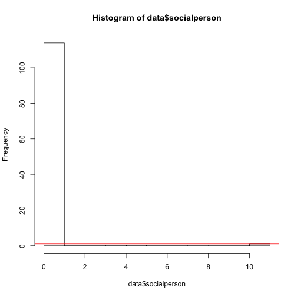

```r
par(mfrow = c(1, 1))
hist(data$socialperson)
abline(h = 1, col = 2) # verify that it is just one erroneous value
```

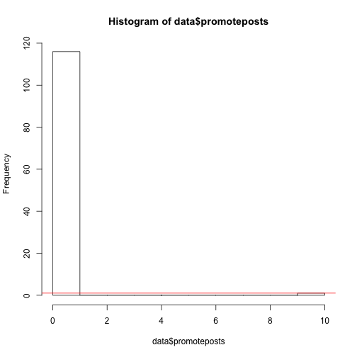

```r
hist(data$promoteposts)
abline(h = 1, col = 2)
```

```r
data$socialperson[data$socialperson == 11] <- NA
data$promoteposts[data$promoteposts == 10] <- NA
```

Convert binary data to categorical

```r
data$highseason <- as.factor(data$highseason)
data$holiday <- as.factor(data$holiday)
data$autoenroll <- as.factor(data$autoenroll)
data$socialperson <- as.factor(data$socialperson)
data$promoteposts <- as.factor(data$promoteposts)
data$learner <- as.factor(data$learner)
```

Convert 'Week' to Date type

```r
data$Week <- as.Date(data$Week, format = '%m/%d/%y')
```

### Explore temporal correlation:

Because these time series, explore temporal effects further in the response variable

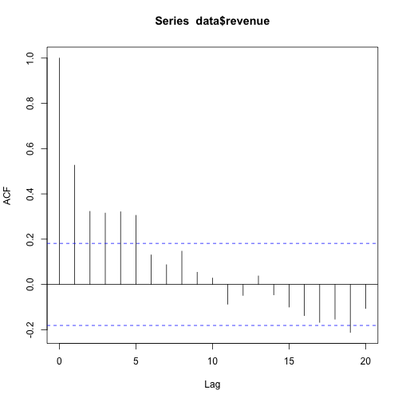

```r
# Check for temporal autocorrelation in revenue values
acf(data$revenue) # yes signif for about 5 weeks lag
```

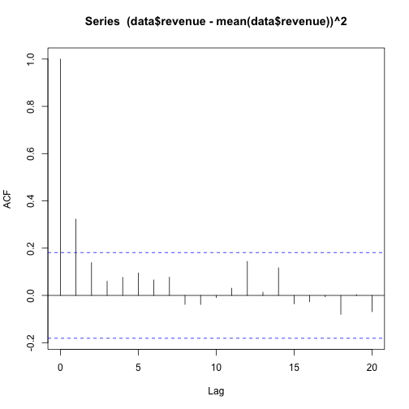

```r
# check for autocorrelation in variance
acf((data$revenue - mean(data$revenue))^2) # slight at best
```

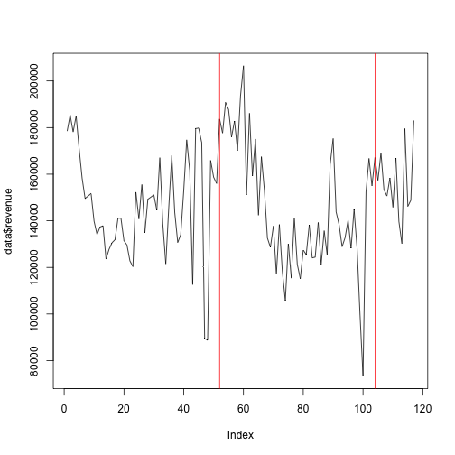

```r
plot(data$revenue, type = 'l')
abline(v = c(52, 104), col = 2) # divisions every 52 weeks (~1 yr)
```

There may be slight autocorrealtion in the variance. There are 20 lags that are being considered in the above graphic, so at the 0.05 significance level (indicated by the blue dashed lines), we expect, on average, one “false positive” in 20, which is exactly what we see here, (though the fact that it is at lag one, makes in potentially suspect as genuinely significant).

With just over 2 years of data, it is not very clear, but there may be a general annnual effect: lower revenue in summer, higher near year ends.

How well does differencing remove autocorrelation?

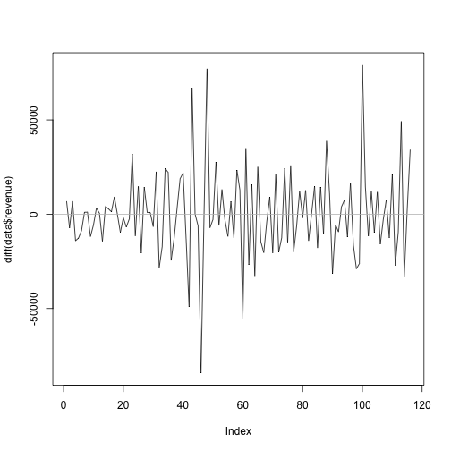

```r
plot(diff(data$revenue), type = 'l')
abline(h = 0, col = 'grey')
```

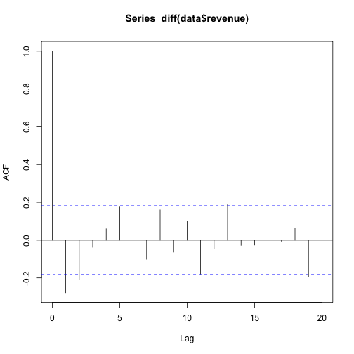

```r
acf(diff(data$revenue))
```

It works pretty well, but note that the differenced distribution has fat tails

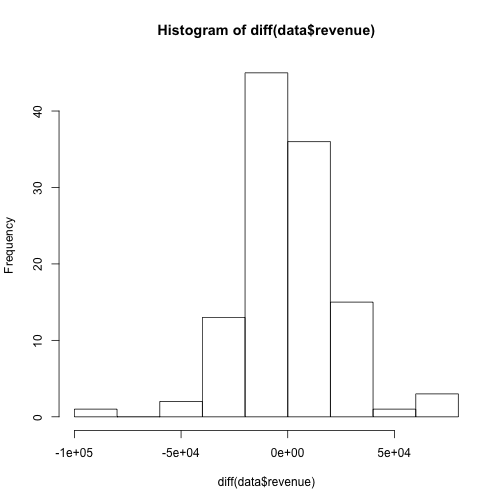

```r
hist(diff(data$revenue))
```

```r
shapiro.test(diff(data$revenue))
```

```
##
##  Shapiro-Wilk normality test
##
## data:  diff(data$revenue)
## W = 0.94573, p-value = 0.0001403
```

Above it could be seen that there is temporal autocorrelation that appears to be significant for about 5 weeks. In the analyses that follow, we allow the preceeding four weeks serve as predictors to account for this autocorrelation. The utility of this approach alone depends on what the goal of the analysis is. If it is to better understand which predictors are significant, this approach is reasonable, as the autocorrelation may serve as a proxy for variables not captures, such as overall state of the economy, interest in IT education at large, etc.

If the goal is forecasting, then the previous weeks' data will not be available, and then time series forecasting will be required to infer these data.

Finally, there are cointegrated time-series approaches that could be used here (as ALL of the predictors are time series), but, as this is a field that I am only just beginning to learn about, I have not attempted these methods here.

Add some potentially useful variables to deal with temporal AC

```r
data$rev1weekAgo <- c(NA,         data$revenue[1:116])
data$rev2weekAgo <- c(rep(NA, 2), data$revenue[1:115])
data$rev3weekAgo <- c(rep(NA, 3), data$revenue[1:114])
data$rev4weekAgo <- c(rep(NA, 4), data$revenue[1:113])
```

Make sure all weeks are evenly spaced (no gaps/missing weeks)

```r
diff(data$Week)
```

```
## Time differences in days
##   [1] 7 7 7 7 7 7 7 7 7 7 7 7 7 7 7 7 7 7 7 7 7 7 7 7 7 7 7 7 7 7 7 7 7 7 7
##  [36] 7 7 7 7 7 7 7 7 7 7 7 7 7 7 7 7 7 7 7 7 7 7 7 7 7 7 7 7 7 7 7 7 7 7 7
##  [71] 7 7 7 7 7 7 7 7 7 7 7 7 7 7 7 7 7 7 7 7 7 7 7 7 7 7 7 7 7 7 7 7 7 7 7
## [106] 7 7 7 7 7 7 7 7 7 7 7
```

There are appx 52 weeks per year–create a new variable telling which week of the year it is (e.g., so seventh week of 2015 can be grouped with seventh week of 2016 to check for annuall effects)

**NOTE:** Data begin on Feb 2

```r
weekOfYear <- (data$weekno + 4) %% 52
weekOfYear[weekOfYear == 0] <- 52
data$weekOfYear <- weekOfYear
# Verify correct alignment
data[47:49, c('Week', 'weekOfYear')]
```

```
##          Week weekOfYear
## 47 2014-12-21         51
## 48 2014-12-28         52
## 49 2015-01-04          1
```

```r
data[52 + 47:49, c('Week', 'weekOfYear')]
```

```
##           Week weekOfYear
## 99  2015-12-20         51
## 100 2015-12-27         52
## 101 2016-01-03          1
```

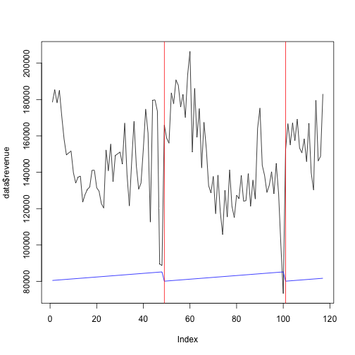

```r
# Visualize
plot(data$revenue, type = 'l')
lines(80000 + 100 * weekOfYear, col = 4)
abline(v = which(weekOfYear == 1), col = 2) # first week of each yr
```

### Add potentially useful transformations of the variables

(These were added after some exploratory analysis: See nuggetAnalysis.R for explanation)

```r
data$fbEngage3 <- data$fbengage^3
data$logSocialpostlag <- (data$socialpostlag)
data$organicnew2 <- data$organicnew^2
data$logOrganicnew <- log(data$organicnew)
data$blognewusers2 <- data$blognewusers^2
data$blognewusersRecip <- 1 / data$blognewusers
data$Fbpostimplag2 <- data$Fbpostimplag^2
data$weekOfYear2 <- data$weekOfYear^2
data$sinWeekOfYear <- sin(pi * (data$weekOfYear + 13) / 26)
data$Twpostimp2 <- data$Twpostimp^2
data$logTwpostimp <- log(data$Twpostimp)

# Store cleaned data
write.csv(data, '~/Desktop/cbtnuggetsbusinessanalyticsproject/revenue/dataClean.csv')
```

### More with Outliers

For “outliers” that may be legitimate data (i.e., not input error), we will want to test models both with the data (assuming that they are correct), and with them removed (assuming they are errors), to compare which performs better.

Replace potential outliers with NA and save as a separate file

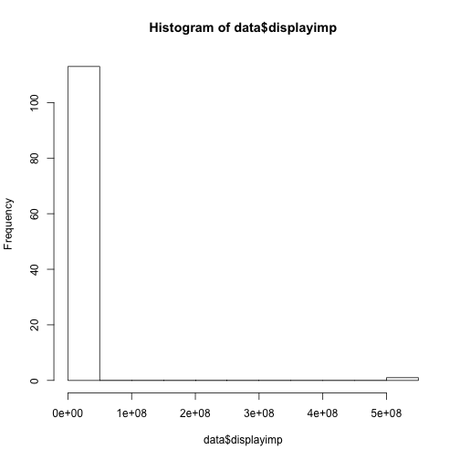

```r
# Potential outliers were in:
# displayimp, displaylag, brandpaid, socialpostimp, Fblikes*, Fbengage*
# *possibly just very skewed data
hist(data$displayimp)
```

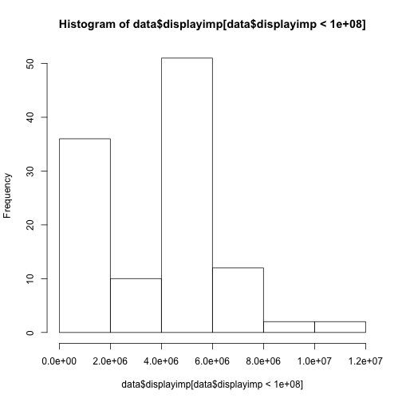

```r
hist(data$displayimp[data$displayimp < 1e+08])
```

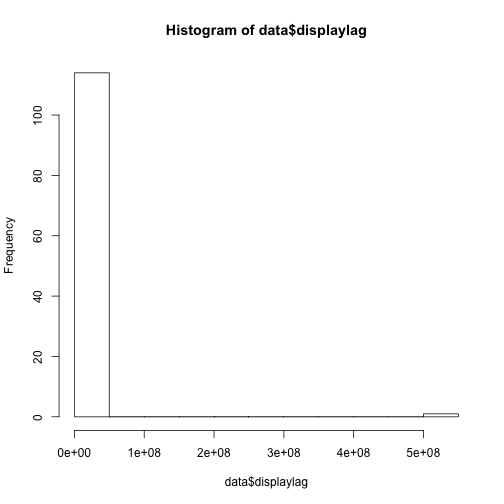

```r
data$displayimp[data$displayimp > 1e+08] <- NA

hist(data$displaylag)
```

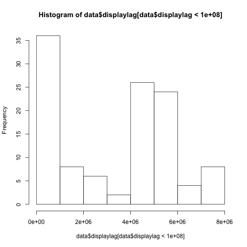

```r
hist(data$displaylag[data$displaylag < 1e+08])
```

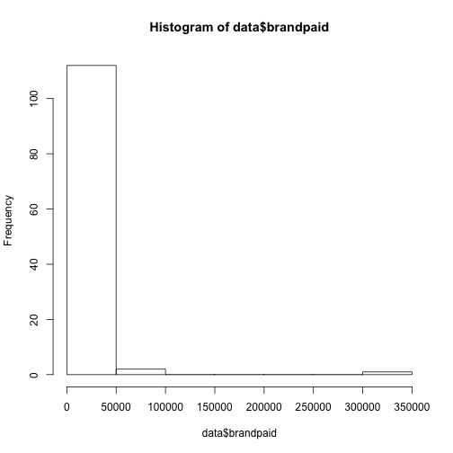

```r
data$displaylag[data$displaylag > 1e+08] <- NA

hist(data$brandpaid)
```

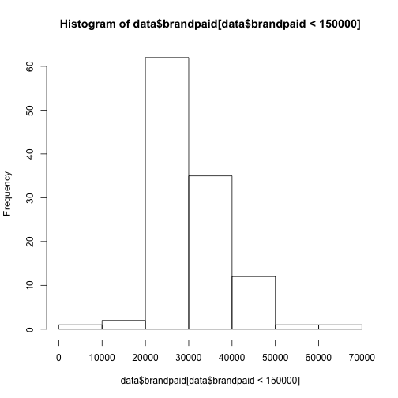

```r
hist(data$brandpaid[data$brandpaid < 150000])
```

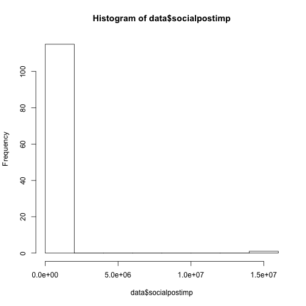

```r
data$brandpaid[data$brandpaid > 150000] <- NA

hist(data$socialpostimp)
```

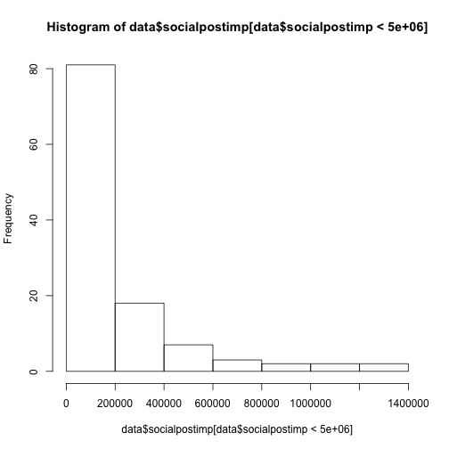

```r
hist(data$socialpostimp[data$socialpostimp < 5e+6])
```

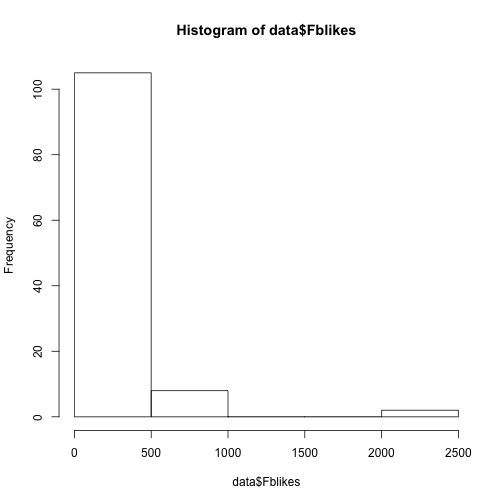

```r
data$socialpostimp[data$socialpostimp > 5e+6] <- NA

# Given the distributions, the following are more likely to be real extreme
# values, and not input errors.  Leave alone for now.
hist(data$Fblikes)
```

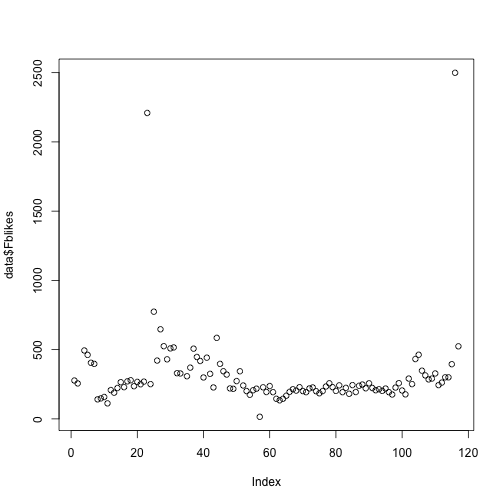

```r
plot(data$Fblikes)
```

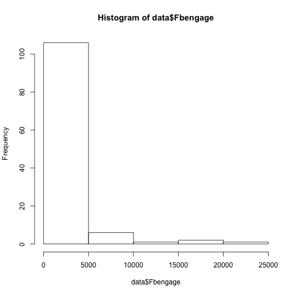

```r
hist(data$Fbengage)
```

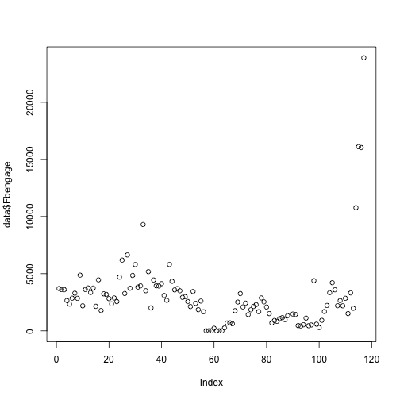

```r
plot(data$Fbengage)
```

```r
# Store the treated data in a separate file.
write.csv(
  data,
  '~/Desktop/cbtnuggetsbusinessanalyticsproject/revenue/dataCleanNoOutlier.csv')
```

**NOTE:** The output .csv files will have an additional first column that indexes the rows that we do not need. Remove them from the data. (Easy to do via Excel).